# Introduction to Classification and Logistic Regression

Python for Business Analytics - Extended Evaluation

Author

Affiliation

Dr. Smith

University of South Florida

# Introduction to Classification and Logistic Regression

In our previous session, we explored **Linear Regression**. We learned how to model the linear relationship between one or more independent variables (features, like `AdvertisingSpend` or `AvgSessionDuration`) and a *continuous* dependent variable (target, like `Sales` or `ConversionRate`). The goal was to predict a specific numerical value, and we evaluated models using metrics like R-squared and RMSE.

Today, we shift our focus to a different type of supervised learning problem: **Classification**.

**What if the outcome we want to predict is categorical, not continuous?**

- Will a customer click on an ad? (Yes/No)
- Is an email spam or not spam? (Spam/Not Spam)
- Will a loan applicant default? (Default/No Default)
- Does a patient have a specific condition? (Positive/Negative)

These are all **classification problems**, where the goal is to assign an observation to one of several predefined categories or classes. For this course, we will focus on **Binary Classification**, where there are only two possible outcome classes (often represented as 0 and 1).

Our main tool for this today will be **Logistic Regression**. But first, let’s understand why we can’t just use the Linear Regression we already know. We will then learn how to build and interpret a logistic regression model and evaluate its performance using **Accuracy** and other crucial metrics like **Precision**, **Recall**, and the **F1-score**, derived from the **Confusion Matrix**.

## Learning Objectives

By the end of this lecture, you should be able to:

1. Explain the difference between Regression and Classification tasks.
2. **Articulate why Linear Regression is generally unsuitable for binary classification problems.**
3. Describe the role of the **Sigmoid (Logistic) function** in Logistic Regression.
4. Explain the goal and mechanics of Binary Logistic Regression.
5. Implement Logistic Regression using Python’s `scikit-learn`.
6. **Interpret the coefficients of a Logistic Regression model (in terms of log-odds and odds ratios).**
7. Make predictions (both class labels and probabilities) using a trained model.
8. **Define and construct a Confusion Matrix for a binary classification problem.**
9. **Calculate and interpret Accuracy, Precision, Recall (Sensitivity), and F1-score from the Confusion Matrix.**
10. **Understand the trade-offs between Precision and Recall and when each metric might be more important.**
11. **Explain the fundamental difference between classification metrics (Accuracy, Precision, Recall, F1) and regression metrics (R-squared/RMSE).**
12. Identify practical business applications of logistic regression.

## Recap: Supervised Learning

Remember, both Linear Regression and Logistic Regression fall under **Supervised Learning**. This means we train our models using labeled data, where we have both the input features (X) and the known correct output (y) for each observation. The model learns a mapping function `f(X) -> y` from this labeled data.

- **Regression:** `y` is a continuous numerical value. (Evaluated with R², RMSE, MAE)
- **Classification:** `y` is a discrete category label (e.g., 0 or 1). (Evaluated with Accuracy, Precision, Recall, F1-score, etc.)

## Why Not Linear Regression for Classification?

Let’s imagine we have data on student study hours and whether they passed an exam (1 = Pass, 0 = Fail). This is a binary classification problem. What happens if we try to fit a standard linear regression line?

```
Libraries imported. Lecture date: April 7, 2025
Global random state set to: 42
--- Sample Exam Pass Data ---
   StudyHours  Passed
0    7.713206       1
1    0.207519       0
2    6.336482       1
3    7.488039       1
4    4.985070       1
```

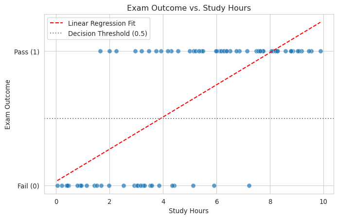

```
--- Problems with Linear Regression for Classification ---
Number of predictions < 0: 0
Number of predictions > 1: 15
Example prediction > 1: 1.08
```

```python
# Setup: Import necessary libraries
import pandas as pd
import numpy as np
import matplotlib.pyplot as plt
import seaborn as sns
from sklearn.linear_model import LinearRegression, LogisticRegression
from sklearn.model_selection import train_test_split
# Import relevant metrics for classification
from sklearn.metrics import accuracy_score, confusion_matrix, precision_score, recall_score, f1_score, classification_report

# Set a style for plots
sns.set_style("whitegrid")
# Set the current date - replace if needed or make dynamic if possible in your environment
current_date_str = "April 7, 2025" # Replace with dynamic date if possible
print(f"Libraries imported. Lecture date: {current_date_str}")

# Set a global random state for reproducibility
GLOBAL_RANDOM_STATE = 42
print(f"Global random state set to: {GLOBAL_RANDOM_STATE}")

# Generate sample data for classification illustration
np.random.seed(10) # Keep original seed for this specific data generation part
study_hours = np.random.rand(80) * 10 # 0 to 10 hours
# Probability increases with hours, add some noise
prob_pass = 1 / (1 + np.exp(-( -4 + 1.0 * study_hours))) # Sigmoid relationship
passed = (prob_pass > np.random.rand(80)).astype(int) # Generate 0/1 based on probability

df_pass = pd.DataFrame({'StudyHours': study_hours, 'Passed': passed})

print("--- Sample Exam Pass Data ---")
print(df_pass.head())

# Visualize the data
plt.figure(figsize=(8, 5))
sns.scatterplot(x='StudyHours', y='Passed', data=df_pass, alpha=0.7, s=50)
plt.yticks([0, 1], ['Fail (0)', 'Pass (1)'])
plt.title('Exam Outcome vs. Study Hours')
plt.xlabel('Study Hours')
plt.ylabel('Exam Outcome')

# Fit a Linear Regression model (for demonstration of why it's bad)
X_lin = df_pass[['StudyHours']]
y_lin = df_pass['Passed']
lin_reg_bad = LinearRegression()
lin_reg_bad.fit(X_lin, y_lin)
y_pred_lin = lin_reg_bad.predict(X_lin)

# Plot the linear regression line
plt.plot(X_lin.sort_values('StudyHours'), np.sort(y_pred_lin), color='red', linestyle='--', label='Linear Regression Fit')
plt.axhline(0.5, color='grey', linestyle=':', label='Decision Threshold (0.5)') # Typical threshold
plt.legend()
plt.show()

print("\n--- Problems with Linear Regression for Classification ---")
# Find predictions outside the [0, 1] range
preds_below_0 = y_pred_lin[y_pred_lin < 0]
preds_above_1 = y_pred_lin[y_pred_lin > 1]
print(f"Number of predictions < 0: {len(preds_below_0)}")
print(f"Number of predictions > 1: {len(preds_above_1)}")
if len(preds_below_0) > 0:
    print(f"Example prediction < 0: {preds_below_0[0]:.2f}")
if len(preds_above_1) > 0:
    print(f"Example prediction > 1: {preds_above_1[-1]:.2f}")
```

Clearly, we need a model designed specifically for this type of outcome, and we also need a different way to evaluate it.

## Logistic Regression: Modeling Probabilities

Logistic Regression addresses these issues. Despite its name, it’s used for **classification**, not regression.

**The Core Idea:** Instead of modeling the outcome `Y` directly, Logistic Regression models the *probability* that `Y` belongs to a particular category (usually denoted as class ‘1’).

**How?** It uses a special mathematical function called the **Sigmoid function** (or Logistic function).

**The Sigmoid Function:**

σ(z) = 1 / (1 + e⁻ᶻ)

Where `e` is the base of the natural logarithm (approx. 2.718) and `z` is the output of a linear equation (just like in linear regression):

$$z
=
β0
+
β1X1
+
β2X2
+
…
+
βpXp$$

**Key Properties of the Sigmoid Function:**

- It takes any real-valued number `z` and maps it to a value between 0 and 1.
- It has an “S” shape, which is great for modeling probabilities that transition from low to high (or vice versa).

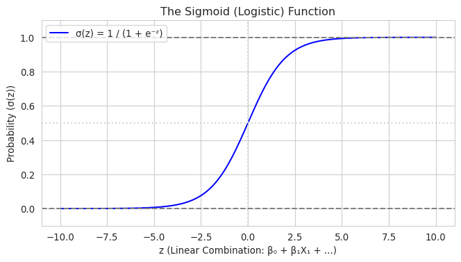

```python
# Visualize the Sigmoid function
def sigmoid(z):
  return 1 / (1 + np.exp(-z))

z_values = np.linspace(-10, 10, 200) # Range of inputs for z
sigma_values = sigmoid(z_values)

plt.figure(figsize=(8, 4))
plt.plot(z_values, sigma_values, label='σ(z) = 1 / (1 + e⁻ᶻ)', color='blue')
plt.axhline(0.0, color='grey', linestyle='--')
plt.axhline(1.0, color='grey', linestyle='--')
plt.axhline(0.5, color='lightgrey', linestyle=':')
plt.axvline(0.0, color='lightgrey', linestyle=':')
plt.title('The Sigmoid (Logistic) Function')
plt.xlabel('z (Linear Combination: β₀ + β₁X₁ + ...)')
plt.ylabel('Probability (σ(z))')
plt.ylim(-0.1, 1.1)
plt.legend()
plt.show()
```

**The Logistic Regression Equation:**

The model calculates the probability of the outcome being class 1 (P(Y=1)) given the input features X:

$$P(Y=1|X)
=
σ(z)
=
1
1
+
e
-
(
β0
+
β1X1
+
β2X2
+
…
+
βpXp
)$$

## Applying Logistic Regression: Study Hours Example

Now that we understand the Sigmoid function and the goal of Logistic Regression, let’s apply it to our initial example: predicting exam passes based on study hours. This will illustrate the workflow with a single feature before we tackle the multi-feature churn case.

```
--- Applying Logistic Regression to Study Hours Data ---
Features shape: (80, 1), Target shape: (80,)
Train set size: 60, Test set size: 20
Pass rate in Test set: 0.60
Logistic Regression model trained on study hours data.

Model Intercept (Log-Odds at 0 hours): -3.1591
Coefficient for StudyHours (Log-Odds change per hour): 0.8981
Odds Ratio for StudyHours: 2.4550
Interpretation: For each additional hour studied, the odds of passing are multiplied by 2.45 (increase by 145.5%)

Visualizing the fitted logistic curve...
```

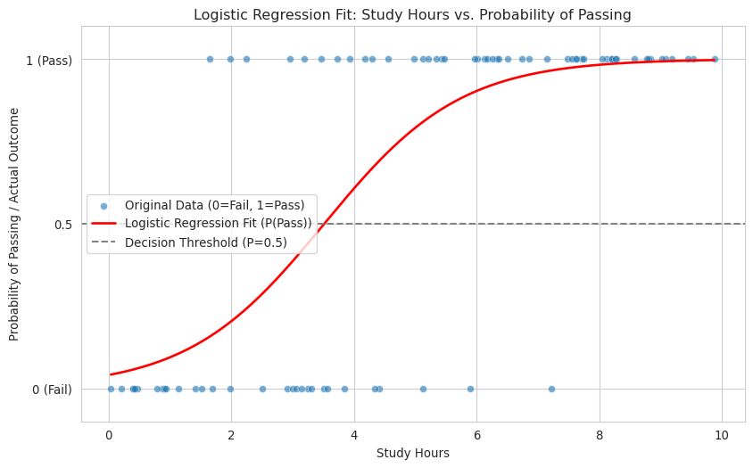

[output not shown]

```python
## Applying Logistic Regression: Study Hours Example
print("\n--- Applying Logistic Regression to Study Hours Data ---")

# 1. Define Features (X) and Target (y) using df_pass from earlier
X_study = df_pass[['StudyHours']]
y_study = df_pass['Passed']
print(f"Features shape: {X_study.shape}, Target shape: {y_study.shape}")

# 2. Train/Test Split
X_study_train, X_study_test, y_study_train, y_study_test = train_test_split(
    X_study, y_study,
    test_size=0.25, # Use 25% for testing
    random_state=GLOBAL_RANDOM_STATE, # Use the global state for reproducibility
    stratify=y_study # Good practice, especially if classes might be imbalanced
)
print(f"Train set size: {X_study_train.shape[0]}, Test set size: {X_study_test.shape[0]}")
print(f"Pass rate in Test set: {y_study_test.mean():.2f}")

# 3. Train the Logistic Regression Model
log_reg_study = LogisticRegression(random_state=GLOBAL_RANDOM_STATE)
log_reg_study.fit(X_study_train, y_study_train)
print("Logistic Regression model trained on study hours data.")

# 4. Interpret Coefficients
intercept_study = log_reg_study.intercept_[0]
coef_study = log_reg_study.coef_[0][0] # Coefficient for StudyHours
odds_ratio_study = np.exp(coef_study)
print(f"\nModel Intercept (Log-Odds at 0 hours): {intercept_study:.4f}")
print(f"Coefficient for StudyHours (Log-Odds change per hour): {coef_study:.4f}")
print(f"Odds Ratio for StudyHours: {odds_ratio_study:.4f}")
print(f"Interpretation: For each additional hour studied, the odds of passing are multiplied by {odds_ratio_study:.2f} (increase by {(odds_ratio_study-1)*100:.1f}%)")

# --- *** ADDED VISUALIZATION START *** ---

# 4b. Visualize the Fitted Logistic Curve
print("\nVisualizing the fitted logistic curve...")

# Generate a range of study hours for plotting the curve
x_plot = np.linspace(X_study['StudyHours'].min(), X_study['StudyHours'].max(), 300).reshape(-1, 1)
# Predict probabilities for this range
y_plot_proba = log_reg_study.predict_proba(x_plot)[:, 1] # Probability of Passing (Class 1)

plt.figure(figsize=(10, 6))
# Plot the original data points (using all data for context)
sns.scatterplot(x='StudyHours', y='Passed', data=df_pass, alpha=0.6, label='Original Data (0=Fail, 1=Pass)')

# Plot the logistic regression curve
plt.plot(x_plot, y_plot_proba, color='red', linewidth=2, label='Logistic Regression Fit (P(Pass))')

# Add a threshold line
plt.axhline(0.5, color='grey', linestyle='--', label='Decision Threshold (P=0.5)')

plt.title('Logistic Regression Fit: Study Hours vs. Probability of Passing')
plt.xlabel('Study Hours')
plt.ylabel('Probability of Passing / Actual Outcome')
plt.yticks([0, 0.5, 1], ['0 (Fail)', '0.5', '1 (Pass)'])
plt.ylim(-0.1, 1.1)
plt.legend(loc='center left')
plt.grid(True)
plt.show()
# --- *** ADDED VISUALIZATION END *** ---


# 5. Make Predictions on Test Set
y_study_pred_labels = log_reg_study.predict(X_study_test)
y_study_pred_proba = log_reg_study.predict_proba(X_study_test)[:, 1] # Prob of Passing

print("\nSample Predictions (Test Set):")
print(f"Actual Pass/Fail:    {y_study_test.iloc[:5].values}")
print(f"Predicted Pass/Fail: {y_study_pred_labels[:5]}")
print(f"Predicted Probability (Pass): {y_study_pred_proba[:5].round(3)}")

# 6. Evaluate the Model
print("\n--- Evaluation Metrics (Study Hours Model - Test Set) ---")
accuracy_study = accuracy_score(y_study_test, y_study_pred_labels)
cm_study = confusion_matrix(y_study_test, y_study_pred_labels)

# Calculate metrics, use zero_division=0 for robustness
precision_study = precision_score(y_study_test, y_study_pred_labels, zero_division=0)
recall_study = recall_score(y_study_test, y_study_pred_labels, zero_division=0)
f1_study = f1_score(y_study_test, y_study_pred_labels, zero_division=0)

print(f"Accuracy:  {accuracy_study:.4f}")
print(f"Precision: {precision_study:.4f}")
print(f"Recall:    {recall_study:.4f}")
print(f"F1-Score:  {f1_study:.4f}")

print("\nConfusion Matrix (Rows=Actual, Cols=Predicted):")
# Rows: Actual (0=Fail, 1=Pass), Cols: Predicted (0=Fail, 1=Pass)
print(cm_study)
tn, fp, fn, tp = cm_study.ravel()
print(f" TN={tn}, FP={fp}, FN={fn}, TP={tp}")


print("\nClassification Report:")
print(classification_report(y_study_test, y_study_pred_labels, target_names=['Fail (0)', 'Pass (1)'], zero_division=0))

print("\nBrief Interpretation: The model achieves a certain accuracy in predicting pass/fail. Precision tells us how often a 'Pass' prediction is correct, while Recall tells us what fraction of actual passers were identified by the model. The plot above visually confirms the positive relationship between study hours and the predicted probability of passing.")
```

This first practical example sets the stage for the more detailed mini-case study that follows.

## Mini-Case: Predicting Customer Churn

Let’s use a more business-relevant example. A telecom company wants to predict which customers are likely to **churn** (stop using their service) based on their account information and usage patterns. This example involves multiple features.

- **Target Variable (y):** `Churn` (1 = Yes, 0 = No) - *Binary*
- **Features (X):**
  - `Account Tenure` (months)
  - `Monthly Charges` ($)
  - *Potentially others like Contract Type, etc.*

*(For simplicity in this lecture, we’ll use generated numerical data resembling tenure and monthly charges).*

```
--- Mini-Case: Customer Churn Data (Sample) ---
      Tenure  MonthlyCharges  Churn
0  44.934283       49.275125      1
1  32.234714       55.995474      0
2  47.953771       88.682340      0
3  65.460597       85.259257      0
4  30.316933       69.477460      0

Churn distribution:
Churn
1    0.533333
0    0.466667
Name: proportion, dtype: float64
```

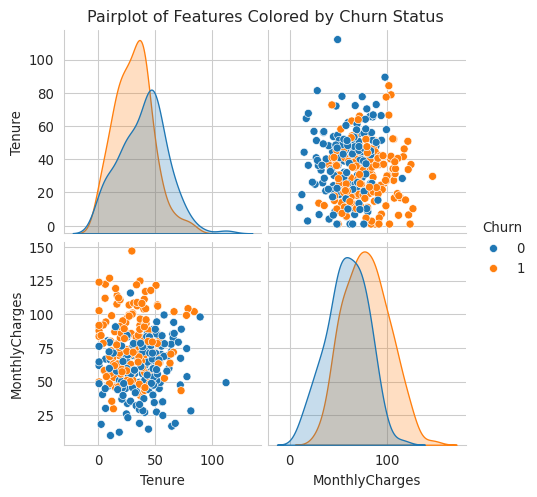

```python
# Generate sample data for Logistic Regression (Customer Churn)
np.random.seed(GLOBAL_RANDOM_STATE) # Use global state for reproducibility
n_customers = 300
tenure = np.random.normal(35, 20, n_customers)
monthly_charges = np.random.normal(70, 25, n_customers)

# Ensure non-negative values
tenure = np.maximum(tenure, 1)
monthly_charges = np.maximum(monthly_charges, 10)

# Create churn probability: Higher charges & lower tenure -> higher probability
# Using the linear combination 'z' inside the sigmoid
# Using slightly different coefficients than the random seed would produce, for illustration consistency
z_churn = -1.8 + 0.045 * monthly_charges - 0.035 * tenure
prob_churn = sigmoid(z_churn)

# Generate Churn outcome (0 or 1)
churn = (prob_churn > np.random.rand(n_customers)).astype(int)

df_churn = pd.DataFrame({
    'Tenure': tenure,
    'MonthlyCharges': monthly_charges,
    'Churn': churn
})

print("\n--- Mini-Case: Customer Churn Data (Sample) ---")
print(df_churn.head())
print("\nChurn distribution:")
print(df_churn['Churn'].value_counts(normalize=True)) # Check class balance

# Visualize relationships (optional but good practice)
sns.pairplot(df_churn, hue='Churn', diag_kind='kde', height=2.5)
plt.suptitle('Pairplot of Features Colored by Churn Status', y=1.02)
plt.show()
```

The pairplot suggests that customers who churn (orange, Churn=1) tend to have lower tenure and potentially higher monthly charges, though there’s overlap.

### Preparing Data (Features X, Target y)

```python
X_churn = df_churn[['Tenure', 'MonthlyCharges']] # Features
y_churn = df_churn['Churn']                      # Target

print("\nShape of X_churn:", X_churn.shape)
print("Shape of y_churn:", y_churn.shape)
```

```
Shape of X_churn: (300, 2)
Shape of y_churn: (300,)
```

### Train-Test Split (Crucial!)

Just like with linear regression and our previous example, we **must** split our data to evaluate the model’s performance on unseen data and check for overfitting.

- **Important Note for Classification:** If your classes are imbalanced (e.g., 95% No Churn, 5% Churn), it’s good practice to use `stratify=y` in `train_test_split`. This ensures that the proportion of classes in the training and test sets is the same as in the original dataset. Our example data is reasonably balanced, but it’s a vital parameter in many real-world scenarios.

```python
X_churn_train, X_churn_test, y_churn_train, y_churn_test = train_test_split(
    X_churn, y_churn,
    test_size=0.25,      # 25% for testing
    random_state=GLOBAL_RANDOM_STATE,     # For reproducibility
    stratify=y_churn     # Ensure class proportions are maintained in splits
)

print("\n--- Churn Train-Test Split ---")
print("Training set size:", X_churn_train.shape[0])
print("Test set size:", X_churn_test.shape[0])
print("\nChurn proportion in Train set:\n", y_churn_train.value_counts(normalize=True))
print("\nChurn proportion in Test set:\n", y_churn_test.value_counts(normalize=True))
```

```
--- Churn Train-Test Split ---
Training set size: 225
Test set size: 75

Churn proportion in Train set:
 Churn
1    0.533333
0    0.466667
Name: proportion, dtype: float64

Churn proportion in Test set:
 Churn
1    0.533333
0    0.466667
Name: proportion, dtype: float64
```

### Training the Logistic Regression Model

```python
# Create and train the Logistic Regression model
# Common parameters:
# C: Inverse of regularization strength (smaller C = stronger regularization). Helps prevent overfitting. Default is 1.0.
# solver: Algorithm to use for optimization. 'liblinear' is good for smaller datasets, 'lbfgs' is common default.
# max_iter: Maximum iterations for the solver to converge.
log_reg_model = LogisticRegression(random_state=GLOBAL_RANDOM_STATE) # Using defaults for now
log_reg_model.fit(X_churn_train, y_churn_train) # Train ONLY on the training data

print("\nLogistic Regression Model trained successfully on Churn data.")
```

```
Logistic Regression Model trained successfully on Churn data.
```

### Interpreting Logistic Regression Coefficients

This is different and slightly more complex than linear regression. The coefficients (β₁, β₂, …) represent the change in the **log-odds** of the outcome (Y=1) for a one-unit increase in the corresponding predictor variable (X), holding other predictors constant.

**Log-Odds (Logit):** `log(p / (1-p))` where `p = P(Y=1 | X)`. This is the natural logarithm of the odds ratio.

**Odds Ratio:** `p / (1-p)`. This represents how many times more likely the event (Y=1) is to occur than not occur. Calculating `exp(coefficient)` gives us the odds ratio, which is often easier to interpret.

```python
# Get intercept and coefficients
log_intercept = log_reg_model.intercept_[0]
log_coefficients = log_reg_model.coef_[0]

feature_names_churn = X_churn_train.columns
coeffs_log_df = pd.DataFrame({'Feature': feature_names_churn, 'Coefficient (Log-Odds)': log_coefficients})

print(f"\n--- Logistic Regression Model Coefficients (Churn Data) ---")
print(f"Intercept (β₀ - Log-Odds when X=0): {log_intercept:.4f}")
print(coeffs_log_df)

# Calculate Odds Ratios (often easier to interpret)
coeffs_log_df['Odds Ratio (exp(β))'] = np.exp(coeffs_log_df['Coefficient (Log-Odds)'])
print("\n--- Odds Ratios ---")
print(coeffs_log_df[['Feature', 'Odds Ratio (exp(β))']])

# Interpretation
print("\nInterpretation:")
print(f"- Intercept ({log_intercept:.4f}): The log-odds of churning when Tenure and MonthlyCharges are both 0 (often not directly interpretable if X=0 is unrealistic).")
print(f"\n- Tenure ({coeffs_log_df.loc[0, 'Coefficient (Log-Odds)']:.4f}):")
print(f"  - Log-Odds: For each additional month of tenure, the log-odds of churning decrease by {abs(coeffs_log_df.loc[0, 'Coefficient (Log-Odds)']):.4f}, holding MonthlyCharges constant.")
print(f"  - Odds Ratio ({coeffs_log_df.loc[0, 'Odds Ratio (exp(β))']:.4f}): For each additional month of tenure, the odds of churning are multiplied by {coeffs_log_df.loc[0, 'Odds Ratio (exp(β))']:.4f} (i.e., they decrease by about {(1-coeffs_log_df.loc[0, 'Odds Ratio (exp(β))'])*100:.1f}%), holding MonthlyCharges constant.")
print(f"\n- MonthlyCharges ({coeffs_log_df.loc[1, 'Coefficient (Log-Odds)']:.4f}):")
print(f"  - Log-Odds: For each additional dollar in monthly charges, the log-odds of churning increase by {coeffs_log_df.loc[1, 'Coefficient (Log-Odds)']:.4f}, holding Tenure constant.")
print(f"  - Odds Ratio ({coeffs_log_df.loc[1, 'Odds Ratio (exp(β))']:.4f}): For each additional dollar in monthly charges, the odds of churning are multiplied by {coeffs_log_df.loc[1, 'Odds Ratio (exp(β))']:.4f} (i.e., they increase by about {(coeffs_log_df.loc[1, 'Odds Ratio (exp(β))']-1)*100:.1f}%), holding Tenure constant.")
```

```
--- Logistic Regression Model Coefficients (Churn Data) ---
Intercept (β₀ - Log-Odds when X=0): -1.8252
          Feature  Coefficient (Log-Odds)
0          Tenure               -0.027858
1  MonthlyCharges                0.042439

--- Odds Ratios ---
          Feature  Odds Ratio (exp(β))
0          Tenure             0.972526
1  MonthlyCharges             1.043353

Interpretation:
- Intercept (-1.8252): The log-odds of churning when Tenure and MonthlyCharges are both 0 (often not directly interpretable if X=0 is unrealistic).

- Tenure (-0.0279):
  - Log-Odds: For each additional month of tenure, the log-odds of churning decrease by 0.0279, holding MonthlyCharges constant.
  - Odds Ratio (0.9725): For each additional month of tenure, the odds of churning are multiplied by 0.9725 (i.e., they decrease by about 2.7%), holding MonthlyCharges constant.

- MonthlyCharges (0.0424):
  - Log-Odds: For each additional dollar in monthly charges, the log-odds of churning increase by 0.0424, holding Tenure constant.
  - Odds Ratio (1.0434): For each additional dollar in monthly charges, the odds of churning are multiplied by 1.0434 (i.e., they increase by about 4.3%), holding Tenure constant.
```

**Key takeaway for interpretation:**

- **Coefficient > 0 (Odds Ratio > 1):** Increasing the predictor increases the odds (and probability) of Y=1.
- **Coefficient < 0 (Odds Ratio < 1):** Increasing the predictor decreases the odds (and probability) of Y=1.
- **Coefficient = 0 (Odds Ratio = 1):** The predictor has no effect on the odds of Y=1 in this model. *(See Appendix A for another example of interpretation.)*

### Making Predictions

Logistic Regression models can make two types of predictions:

1. **Predicted Class Labels:** The most likely class (0 or 1). By default, `scikit-learn` uses a probability threshold of 0.5. If P(Y=1) > 0.5, predict 1; otherwise, predict 0. Use `model.predict()`.
2. **Predicted Probabilities:** The actual probability P(Y=1) and P(Y=0) for each observation. This is often more useful for business decisions (e.g., targeting customers with a high *probability* of churn, even if it’s below 0.5). Use `model.predict_proba()`.

```python
# 1. Predict Class Labels on the TEST set
y_churn_pred_labels = log_reg_model.predict(X_churn_test)

# 2. Predict Probabilities on the TEST set
y_churn_pred_proba = log_reg_model.predict_proba(X_churn_test)

print("\n--- Predictions on Churn Test Set ---")
print("First 5 Actual Labels:   ", y_churn_test.iloc[:5].values)
print("First 5 Predicted Labels:", y_churn_pred_labels[:5])
print("\nFirst 5 Predicted Probabilities (P(Y=0), P(Y=1)):")
print(y_churn_pred_proba[:5].round(4))

# Show how labels relate to probabilities (using default 0.5 threshold)
# Extract probability of class 1 (second column)
prob_class_1_churn = y_churn_pred_proba[:, 1]
print("\nFirst 5 Probabilities for Class 1 (Churn):", prob_class_1_churn[:5].round(4))
print("Labels derived using 0.5 threshold:       ", (prob_class_1_churn[:5] > 0.5).astype(int))
```

```
--- Predictions on Churn Test Set ---
First 5 Actual Labels:    [0 0 0 0 0]
First 5 Predicted Labels: [0 0 0 0 0]

First 5 Predicted Probabilities (P(Y=0), P(Y=1)):
[[0.7955 0.2045]
 [0.5767 0.4233]
 [0.5392 0.4608]
 [0.6261 0.3739]
 [0.8277 0.1723]]

First 5 Probabilities for Class 1 (Churn): [0.2045 0.4233 0.4608 0.3739 0.1723]
Labels derived using 0.5 threshold:        [0 0 0 0 0]
```

Notice that `predict_proba` returns two columns: the probability of class 0 and the probability of class 1. They always sum to 1. The `predict` method simply picks the class with the higher probability (equivalent to checking if P(Y=1) > 0.5). *(See Appendix B for how changing the threshold affects predictions.)*

### Evaluating the Logistic Regression Model using Accuracy

Okay, now let’s evaluate how well our model did on the test set. Since this is a classification problem, we **cannot** use R-squared or RMSE. Those metrics measure how close a predicted *number* is to an actual *number*. Here, we’re predicting *categories* (Churn=1 or Churn=0).

Our first metric will be **Accuracy**.

**Accuracy:** * The most straightforward classification metric. * It measures the overall proportion of predictions that the model got correct. * Formula: `Accuracy = (Number of Correct Predictions) / (Total Number of Predictions)`

```python
# Calculate Accuracy using the predicted labels and the true labels from the test set
accuracy_churn = accuracy_score(y_churn_test, y_churn_pred_labels)

print(f"\n--- Evaluation Metric: Accuracy (Churn Model) ---")
print(f"Accuracy Score on Test Set: {accuracy_churn:.4f} ({(accuracy_churn*100):.2f}%)")
print(f"\nThis means the model correctly predicted whether a customer would churn or not for {accuracy_churn*100:.2f}% of the customers in the unseen test data.")
```

```
--- Evaluation Metric: Accuracy (Churn Model) ---
Accuracy Score on Test Set: 0.7467 (74.67%)

This means the model correctly predicted whether a customer would churn or not for 74.67% of the customers in the unseen test data.
```

While accuracy is easy to understand, it can sometimes be misleading, especially if the classes are imbalanced or if the costs of different types of errors are unequal (more on this now!).

## Beyond Accuracy: The Confusion Matrix and Key Metrics

Accuracy gives us an overall sense of performance, but it doesn’t tell us *what kind* of errors the model is making. To get a deeper understanding, we use the **Confusion Matrix**.

**The Confusion Matrix**

A confusion matrix is a table that summarizes the performance of a classification model by comparing the predicted class labels against the actual class labels. For a binary classification problem (like our churn example: 0=No Churn, 1=Churn), it looks like this:

|  | Predicted: No Churn (0) | Predicted: Churn (1) |
| --- | --- | --- |
| **Actual: No Churn (0)** | True Negative (TN) | False Positive (FP) |
| **Actual: Churn (1)** | False Negative (FN) | True Positive (TP) |

Where:

- **True Positive (TP):** The model correctly predicted ‘Churn’ (1) when the customer actually did churn (1).
- **True Negative (TN):** The model correctly predicted ‘No Churn’ (0) when the customer actually did not churn (0).
- **False Positive (FP):** (Type I Error) The model incorrectly predicted ‘Churn’ (1) when the customer actually did *not* churn (0). (Predicted positive, but it was false).
- **False Negative (FN):** (Type II Error) The model incorrectly predicted ‘No Churn’ (0) when the customer actually *did* churn (1). (Predicted negative, but it was false).

**Our Goal:** Maximize TP and TN, while minimizing FP and FN.

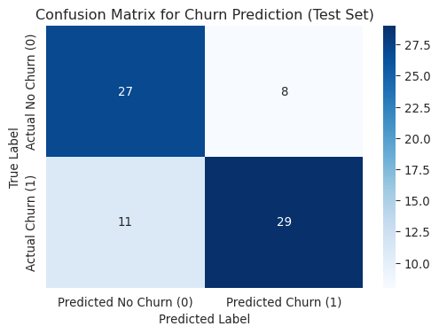

```
--- Confusion Matrix Components (Churn Model) ---
True Negatives (TN): 27 (Correctly predicted 'No Churn')
False Positives (FP): 8 (Incorrectly predicted 'Churn')
False Negatives (FN): 11 (Incorrectly predicted 'No Churn')
True Positives (TP): 29 (Correctly predicted 'Churn')
```

```python
# Generate the confusion matrix for the churn model
cm_churn = confusion_matrix(y_churn_test, y_churn_pred_labels)

# For better visualization, let's use seaborn's heatmap
plt.figure(figsize=(6, 4))
sns.heatmap(cm_churn, annot=True, fmt='d', cmap='Blues',
            xticklabels=['Predicted No Churn (0)', 'Predicted Churn (1)'],
            yticklabels=['Actual No Churn (0)', 'Actual Churn (1)'])
plt.xlabel('Predicted Label')
plt.ylabel('True Label')
plt.title('Confusion Matrix for Churn Prediction (Test Set)')
plt.show()

# Extract values (optional, for clarity)
tn_churn, fp_churn, fn_churn, tp_churn = cm_churn.ravel()
print("\n--- Confusion Matrix Components (Churn Model) ---")
print(f"True Negatives (TN): {tn_churn} (Correctly predicted 'No Churn')")
print(f"False Positives (FP): {fp_churn} (Incorrectly predicted 'Churn')")
print(f"False Negatives (FN): {fn_churn} (Incorrectly predicted 'No Churn')")
print(f"True Positives (TP): {tp_churn} (Correctly predicted 'Churn')")
```

### Metrics Derived from the Confusion Matrix

The confusion matrix allows us to calculate more nuanced metrics:

**1. Accuracy (Revisited):** The proportion of all predictions that were correct. * Formula: `(TP + TN) / (TP + TN + FP + FN)` * Interpretation: Overall correctness. We already calculated this.

**2. Precision:** Out of all the instances the model *predicted* as positive (Churn), what proportion actually *were* positive? * Formula: `TP / (TP + FP)` * Interpretation: Measures the accuracy of the positive predictions. High precision means that when the model predicts churn, it’s likely correct. Minimizes False Positives. * *Business Question:* When we flag a customer as likely to churn, how often are we right? (Important if the cost of intervention for a non-churner is high).

**3. Recall (Sensitivity or True Positive Rate):** Out of all the instances that *actually were* positive (Churn), what proportion did the model correctly *identify*? * Formula: `TP / (TP + FN)` * Interpretation: Measures how well the model finds all the positive instances. High recall means the model catches most of the actual churners. Minimizes False Negatives. * *Business Question:* Of all the customers who actually churned, how many did we successfully identify? (Important if the cost of missing a churner is very high).

**4. F1-Score:** The harmonic mean of Precision and Recall. It provides a single score that balances both concerns. * Formula: `2 * (Precision * Recall) / (Precision + Recall)` * Interpretation: Useful when you need a balance between Precision and Recall, especially if the class distribution is uneven. It’s high only when both precision and recall are high.

```python
# Calculate Precision, Recall, and F1-score for the churn model
# Use zero_division=0 to avoid warnings if a metric calculation results in 0/0
precision_churn = precision_score(y_churn_test, y_churn_pred_labels, zero_division=0)
recall_churn = recall_score(y_churn_test, y_churn_pred_labels, zero_division=0)
f1_churn = f1_score(y_churn_test, y_churn_pred_labels, zero_division=0)

print("\n--- Key Classification Metrics (Churn Model) ---")
print(f"Accuracy:  {accuracy_churn:.4f}") # From earlier calculation
print(f"Precision: {precision_churn:.4f}")
print(f"Recall:    {recall_churn:.4f}")
print(f"F1-Score:  {f1_churn:.4f}")

print("\nInterpretation Recap:")
print(f"- Precision ({precision_churn:.4f}): When the model predicts a customer will churn, it is correct {precision_churn*100:.1f}% of the time.")
print(f"- Recall ({recall_churn:.4f}): The model correctly identifies {recall_churn*100:.1f}% of all customers who actually churned.")
print(f"- F1-Score ({f1_churn:.4f}): A combined measure balancing precision and recall.")

# Scikit-learn also provides a handy classification report
print("\n--- Classification Report (Comprehensive Summary - Churn Model) ---")
print(classification_report(y_churn_test, y_churn_pred_labels, target_names=['No Churn (0)', 'Churn (1)'], zero_division=0))
```

```
--- Key Classification Metrics (Churn Model) ---
Accuracy:  0.7467
Precision: 0.7838
Recall:    0.7250
F1-Score:  0.7532

Interpretation Recap:
- Precision (0.7838): When the model predicts a customer will churn, it is correct 78.4% of the time.
- Recall (0.7250): The model correctly identifies 72.5% of all customers who actually churned.
- F1-Score (0.7532): A combined measure balancing precision and recall.

--- Classification Report (Comprehensive Summary - Churn Model) ---
              precision    recall  f1-score   support

No Churn (0)       0.71      0.77      0.74        35
   Churn (1)       0.78      0.72      0.75        40

    accuracy                           0.75        75
   macro avg       0.75      0.75      0.75        75
weighted avg       0.75      0.75      0.75        75
```

**Precision-Recall Trade-off:**

Often, improving Precision comes at the cost of reducing Recall, and vice versa. (See Appendix B on Thresholding). * Lowering the probability threshold to classify more people as ‘Churn’ will likely increase Recall (catch more actual churners) but decrease Precision (more non-churners will be incorrectly flagged). * Raising the threshold will likely increase Precision (be more confident when predicting churn) but decrease Recall (miss more actual churners). The choice depends on the business problem: Is it worse to miss a churner (need higher Recall) or to waste resources on a non-churner (need higher Precision)?

### Accuracy vs. Regression Metrics (R², RMSE, MAE): Why the Difference?

It’s crucial to understand *why* we use these classification metrics here and R²/RMSE for linear regression:

1. **Type of Prediction:**
   - **Linear Regression:** Predicts a *continuous numerical value* (e.g., sales dollars, temperature, score).
   - **Logistic Regression (Classification):** Predicts a *discrete category label* (e.g., Yes/No, 0/1, Spam/Not Spam).
2. **What the Metric Measures:**
   - **R-squared:** Measures the *proportion of variance* in the continuous target variable explained by the model.
   - **RMSE/MAE:** Measure the *average prediction error* in the original units of the continuous target.
   - **Accuracy, Precision, Recall, F1:** Measure different aspects of *correctness in categorization*, considering true/false positives/negatives. They don’t measure numerical distance but rather the counts of correct/incorrect assignments to discrete bins.

**Analogy:**

- **Regression Evaluation (RMSE/MAE):** Like grading an exam where partial credit is given based on how close the answer is to the correct number.
- **Classification Evaluation (Confusion Matrix Metrics):** Like grading a medical diagnosis test - you need to know not just overall accuracy, but specifically how many sick people were missed (FN) and how many healthy people were misdiagnosed (FP).

*(See Appendix C for a reminder about imbalanced data).*

### Prediction Example using Probabilities for Decision Making

Even though we evaluate with a suite of metrics based on the 0/1 labels (often derived using a 0.5 threshold), the underlying probabilities from `predict_proba` are often more useful for business decisions, allowing us to set custom thresholds based on business needs and the Precision/Recall trade-off.

```python
# Predict churn probability for new hypothetical customers
new_customers = pd.DataFrame({
    'Tenure': [5, 60, 24],        # Low, High, Medium tenure
    'MonthlyCharges': [100, 50, 75] # High, Low, Medium charges
})

predicted_churn_probs_new = log_reg_model.predict_proba(new_customers)[:, 1] # Get P(Churn=1)
predicted_churn_labels_new = log_reg_model.predict(new_customers) # Get label based on 0.5 threshold

print(f"\n--- Logistic Regression Prediction Example (Probabilities & Labels) ---")
results_df = new_customers.copy()
results_df['Predicted Churn Probability'] = predicted_churn_probs_new
results_df['Predicted Label (0.5 Threshold)'] = predicted_churn_labels_new
# Example of a business rule using a different threshold (e.g., targeting high-risk)
results_df['Action (if P(Churn) > 0.7)'] = np.where(results_df['Predicted Churn Probability'] > 0.7, 'Offer High-Value Retention Discount', 'No Action / Standard Marketing')
# Example rule focusing on catching more potential churners (lower threshold)
results_df['Risk Segment (if P(Churn) > 0.4)'] = np.where(results_df['Predicted Churn Probability'] > 0.4, 'Moderate Risk - Monitor', 'Low Risk')

print(results_df)
```

```
--- Logistic Regression Prediction Example (Probabilities & Labels) ---
   Tenure  MonthlyCharges  Predicted Churn Probability  \
0       5             100                     0.907162
1      60              50                     0.201860
2      24              75                     0.665783

   Predicted Label (0.5 Threshold)           Action (if P(Churn) > 0.7)  \
0                                1  Offer High-Value Retention Discount
1                                0       No Action / Standard Marketing
2                                1       No Action / Standard Marketing

  Risk Segment (if P(Churn) > 0.4)
0          Moderate Risk - Monitor
1                         Low Risk
2          Moderate Risk - Monitor
```

This shows how probabilities allow flexible decision-making informed by the trade-offs highlighted by Precision and Recall.

**Visualizing Model Fit: Underfitting vs. Overfitting**

#### The Balancing Act: Bias vs. Variance

*(This section remains the same as the concept applies broadly to model fitting)*

When we build predictive models, we’re constantly trying to strike a balance. We want a model that learns the true underlying patterns in our data but doesn’t just memorize the noise or random fluctuations specific to our training set. This leads to two common problems:

1. **Underfitting (High Bias):**
   - **What it is:** The model is *too simple* to capture the underlying structure of the data. It fails to learn the relationship between the features (X) and the target (y).
   - **Symptoms:** Poor performance on *both* the training data and the test data. The model doesn’t represent the data well.
   - **Visual:** The model’s decision boundary (the line or curve separating the classes) is too simplistic and misclassifies many points in both sets.
2. **Overfitting (High Variance):**
   - **What it is:** The model learns the training data *too well*, including the random noise. It essentially memorizes the training examples instead of learning the general trend.
   - **Symptoms:** Excellent performance on the training data but poor performance on new, unseen data (the test set). The model doesn’t generalize well.
   - **Visual:** The model’s decision boundary is overly complex, fitting tightly around the training points, potentially leading to strange classifications for new data.
3. **Good Fit (The “Goldilocks” Zone):**
   - **What it is:** The model captures the underlying trend of the data effectively without fitting the noise.
   - **Symptoms:** Good performance on both the training data and, more importantly, the test data. The model generalizes well to new examples.
   - **Visual:** The model’s decision boundary appropriately separates the classes while remaining relatively smooth and generalizable.

**Our Goal:** Find a model that achieves a good balance – complex enough to capture the trend (avoiding underfitting) but simple enough to avoid fitting noise and generalize well (avoiding overfitting). Techniques like train-test split help us *diagnose* these issues by evaluating performance on unseen data. Regularization (controlled by the `C` parameter in `LogisticRegression`) is a common technique to prevent overfitting.

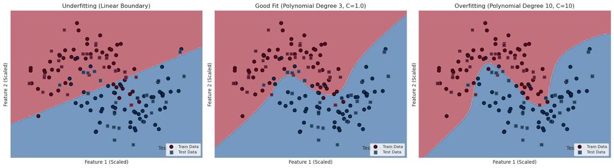

Illustration of Decision Boundaries: Underfitting, Good Fit, Overfitting

## Business Applications Revisited

Logistic regression is a workhorse in business analytics for classification tasks:

- **Marketing:** Predicting customer churn, click-through rate on ads, conversion likelihood for leads. *(Evaluation might prioritize Recall to catch churners or Precision to target ads efficiently).*
- **Finance:** Credit scoring (predicting loan default risk), fraud detection (predicting fraudulent transactions). *(Evaluation might prioritize Recall for fraud detection or a balance for credit scoring).*
- **Healthcare:** Predicting patient diagnosis based on symptoms, predicting hospital readmission risk. *(Evaluation often prioritizes Recall/Sensitivity to avoid missing diagnoses).*
- **Human Resources:** Predicting employee attrition (leaving the company).
- **Operations:** Predicting equipment failure, predicting whether a shipment will arrive on time.

## Conclusion

Today, we transitioned from predicting continuous values (regression) to predicting categories (classification). Key takeaways include:

1. **Classification** aims to assign observations to predefined categories (e.g., Yes/No, 0/1).
2. **Linear Regression is unsuitable** for classification because its output isn’t constrained to [0, 1] and doesn’t fit probabilistic transitions well.
3. **Logistic Regression** uses the **Sigmoid function** to model the *probability* of an outcome belonging to class 1, outputting values between 0 and 1.
4. Coefficients in Logistic Regression relate to **log-odds**, and **odds ratios** (`exp(coefficient)`) provide a more interpretable measure of effect size.
5. **Train-Test Split** is essential for unbiased model evaluation. Use `stratify=y` for potentially imbalanced classes.
6. Evaluating classification models requires metrics beyond simple accuracy. The **Confusion Matrix** provides the foundation by showing TP, TN, FP, FN.
7. **Accuracy** measures overall correctness: `(TP+TN)/Total`.
8. **Precision** measures positive predictive value: `TP/(TP+FP)`. Answers: “Of those we predicted positive, how many were actually positive?”
9. **Recall** (Sensitivity) measures true positive rate: `TP/(TP+FN)`. Answers: “Of those that were actually positive, how many did we find?”
10. **F1-Score** is the harmonic mean of Precision and Recall, offering a balanced view: `2*(Precision*Recall)/(Precision+Recall)`.
11. There is often a **trade-off between Precision and Recall**, influenced by the classification threshold. The choice depends on the relative costs of False Positives vs. False Negatives.
12. **Classification metrics differ significantly from R²/RMSE/MAE**; they assess categorical correctness, while R²/RMSE/MAE assess the magnitude and variance explained for numerical predictions.
13. Logistic Regression provides both class label predictions (`predict`) and probability predictions (`predict_proba`), the latter being crucial for nuanced decision-making and threshold adjustments.

Logistic Regression is a foundational and widely used classification algorithm. Understanding its evaluation metrics is critical for building and interpreting effective classification models.

**Next Steps:** We can now apply these evaluation techniques to other classification algorithms we might encounter, such as Decision Trees or Support Vector Machines. We can also explore techniques like ROC curves and AUC to visualize and evaluate model performance across *all possible* thresholds.

Think about the binary decisions made in businesses you know. Where could you potentially apply logistic regression, and would Precision or Recall be the more critical metric for evaluation?

# Appendix

## Appendix A: Interpreting Odds Ratios - Another Look

*(Note: Actual OR values depend on the specific model fit)*

**Simplified Example:** Imagine a model predicting online purchase (1=Yes, 0=No) based only on `TimeOnSite` (minutes). If the coefficient for `TimeOnSite` is 0.2, the odds ratio is `exp(0.2) ≈ 1.22`. *Interpretation:* For each additional minute a user spends on the site, their odds of making a purchase increase by about 22% (multiplied by 1.22).

## Appendix B: Probability Thresholds and Predictions (Impacting Precision/Recall)

The `predict()` method in scikit-learn uses a default probability threshold of 0.5 to convert probabilities from `predict_proba()` into class labels (0 or 1). Changing this threshold directly impacts the number of False Positives and False Negatives, thus changing Precision and Recall.

```python
print("--- Appendix B: Thresholding ---")
# Using the results_df from the churn prediction example
print("Original Data & Probabilities:")
print(results_df[['Tenure', 'MonthlyCharges', 'Predicted Churn Probability']])

# Get probabilities P(Churn=1) for the three hypothetical customers
probs_churn = results_df['Predicted Churn Probability'].values

# Apply different thresholds
threshold_0_5 = 0.5 # Default
threshold_0_7 = 0.7 # Higher threshold (stricter for predicting Churn=1)
threshold_0_3 = 0.3 # Lower threshold (looser for predicting Churn=1)

predictions_at_0_5 = (probs_churn > threshold_0_5).astype(int)
predictions_at_0_7 = (probs_churn > threshold_0_7).astype(int)
predictions_at_0_3 = (probs_churn > threshold_0_3).astype(int)

threshold_df = pd.DataFrame({
    'Probability P(Churn=1)': probs_churn.round(4),
    f'Prediction (Thresh={threshold_0_5})': predictions_at_0_5,
    f'Prediction (Thresh={threshold_0_7})': predictions_at_0_7,
    f'Prediction (Thresh={threshold_0_3})': predictions_at_0_3
})

print("\nPredictions at Different Thresholds:")
print(threshold_df)

print("\nObservations:")
# Note: Actual probabilities depend on the model run
example_prob_cust1 = probs_churn[0]
print(f"- Using threshold={threshold_0_5}, customer 1 (P={example_prob_cust1:.3f}) prediction depends on whether P > 0.5.")
print(f"- Using threshold={threshold_0_7}, customer 1 prediction depends on whether P > 0.7.")
print(f"- Using threshold={threshold_0_3}, customer 1 prediction depends on whether P > 0.3.")
```

```
--- Appendix B: Thresholding ---
Original Data & Probabilities:
   Tenure  MonthlyCharges  Predicted Churn Probability
0       5             100                     0.907162
1      60              50                     0.201860
2      24              75                     0.665783

Predictions at Different Thresholds:
   Probability P(Churn=1)  Prediction (Thresh=0.5)  Prediction (Thresh=0.7)  \
0                  0.9072                        1                        1
1                  0.2019                        0                        0
2                  0.6658                        1                        0

   Prediction (Thresh=0.3)
0                        1
1                        0
2                        1

Observations:
- Using threshold=0.5, customer 1 (P=0.907) prediction depends on whether P > 0.5.
- Using threshold=0.7, customer 1 prediction depends on whether P > 0.7.
- Using threshold=0.3, customer 1 prediction depends on whether P > 0.3.
```

**Impact on Metrics (Conceptual):**

- **Raising Threshold (e.g., 0.5 -> 0.7):** Fewer instances are predicted as Positive (1). This generally *decreases TP* and *decreases FP*. Consequence: **Precision likely increases** (fewer false alarms among positive predictions), **Recall likely decreases** (more actual positives might be missed, becoming FN).
- **Lowering Threshold (e.g., 0.5 -> 0.3):** More instances are predicted as Positive (1). This generally *increases TP* and *increases FP*. Consequence: **Precision likely decreases** (more false alarms among positive predictions), **Recall likely increases** (fewer actual positives are missed).

This decision depends entirely on the business context and the relative cost of FP vs. FN errors. `predict_proba()` allows *you* to apply the threshold that best balances Precision and Recall for your specific needs. Evaluating models properly often involves considering performance across different thresholds (which leads to techniques like ROC curves).

## Appendix C: Importance of Metrics Beyond Accuracy (Especially with Imbalanced Data)

As discussed in the main text, accuracy alone can be misleading, particularly when dealing with **imbalanced datasets** (where one class is much more frequent than the other).

Imagine a fraud detection system where only 0.1% of transactions are fraudulent. A model predicting “Not Fraud” for every transaction would achieve 99.9% accuracy! However, it would have 0% Recall for fraud cases, making it useless for its intended purpose.

In such scenarios:

- **Precision** tells you how trustworthy a “Fraud” prediction is.
- **Recall** tells you how many actual fraud cases the model managed to find.
- **F1-Score** provides a balance if both are important.

Always examine the confusion matrix and metrics like Precision and Recall, especially when classes are imbalanced or the costs of different errors vary significantly.